# Assignment1_WenyueShi

Wenyue Shi

August 5, 2015

## Set a global seed

```r
set.seed(1984)
```

## Exploratory analysis

Load the mosaic library and import the data

```r
library(mosaic)
vote = read.csv('../data/georgia2000.csv')
```

Take a look at the data frame by looking at the summary.

```r
summary(vote)
```

```
##       county       ballots           votes            equip
##  APPLING :  1   Min.   :   881   Min.   :   832   LEVER  :74
##  ATKINSON:  1   1st Qu.:  3694   1st Qu.:  3506   OPTICAL:66
##  BACON   :  1   Median :  6712   Median :  6299   PAPER  : 2
##  BAKER   :  1   Mean   : 16926   Mean   : 16331   PUNCH  :17
##  BALDWIN :  1   3rd Qu.: 12251   3rd Qu.: 11846
##  BANKS   :  1   Max.   :280975   Max.   :263211
##  (Other) :153
##       poor            urban           atlanta            perAA
##  Min.   :0.0000   Min.   :0.0000   Min.   :0.00000   Min.   :0.0000
##  1st Qu.:0.0000   1st Qu.:0.0000   1st Qu.:0.00000   1st Qu.:0.1115
##  Median :0.0000   Median :0.0000   Median :0.00000   Median :0.2330
##  Mean   :0.4528   Mean   :0.2642   Mean   :0.09434   Mean   :0.2430
##  3rd Qu.:1.0000   3rd Qu.:1.0000   3rd Qu.:0.00000   3rd Qu.:0.3480
##  Max.   :1.0000   Max.   :1.0000   Max.   :1.00000   Max.   :0.7650
##
##       gore             bush
##  Min.   :   249   Min.   :   271
##  1st Qu.:  1386   1st Qu.:  1804
##  Median :  2326   Median :  3597
##  Mean   :  7020   Mean   :  8929
##  3rd Qu.:  4430   3rd Qu.:  7468
##  Max.   :154509   Max.   :140494
##
```

Calculate the undercount_percentage $(ballots - votes) / ballots$ and add the percentage to the original data set.

```r
diff = vote$ballots - vote$votes
vote$diff <- diff
diff_ballots = vote$diff/vote$ballots
vote$diff_ballots = diff_ballots
```

Boxplot the percentage:

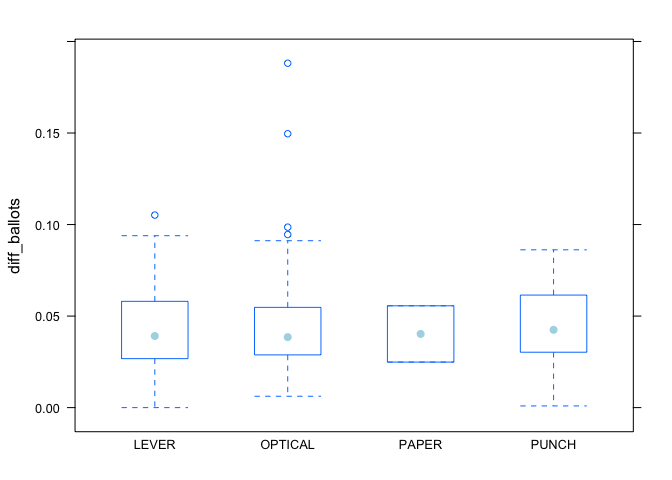

```r
bwplot(diff_ballots~equip, data = vote, col = "Light Blue", outline = FALSE)
```

From the boxplot, in general, different equipment of voting does not lead to higher rate of undercount.

### Poor Areas

But then we want to see whether different equipment does affect undercount in poor area. Select the poor observation out, where $poor = 1$ and plot the undercount percentage again with the boxplot.

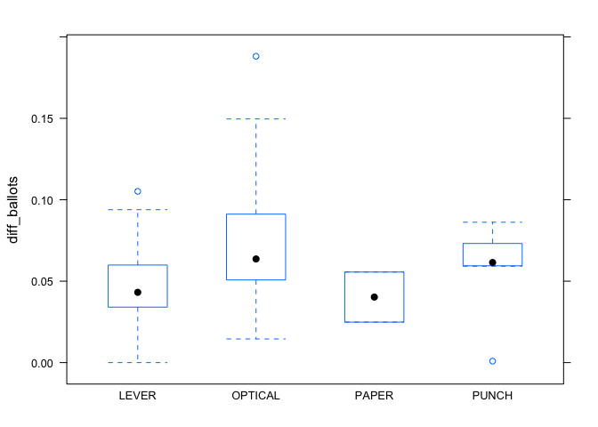

```r
poor <- vote[vote$poor == 1, ]
bwplot(diff_ballots~equip, data = poor)
```

Obviously, optical and punch lead to a higher level of undercount than lever and paper. To compare with non-poor areas, I did the similar thing to non-poor area.

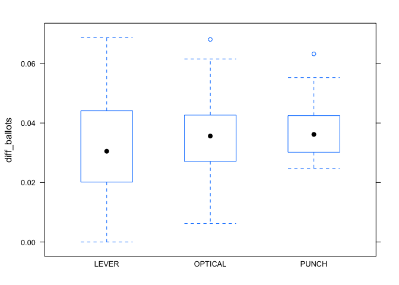

```r
notpoor <- vote[vote$poor == 0, ]
bwplot(diff_ballots~equip, data = notpoor)
```

Clearly, equipment doesn’t obviously affect the undercount level, even though optical and punch still generate a little bit higher undercount.

Overall, poor areas have

- higher undercount_percentage than non-poor areas
- remarkable different undercount value with different equipments

### Minority Areas

```r
lever = vote[vote$equip == 'LEVER', ]
optical = vote[vote$equip == 'OPTICAL', ]
paper = vote[vote$equip == 'PAPER', ]
punch = vote[vote$equip == 'PUNCH', ]

lm.lever = lm(diff_ballots~perAA, data = lever)
summary(lm.lever)
```

```
##
## Call:
## lm(formula = diff_ballots ~ perAA, data = lever)
##
## Residuals:
##       Min        1Q    Median        3Q       Max
## -0.042857 -0.014572 -0.003374  0.015299  0.062319
##
## Coefficients:
##              Estimate Std. Error t value Pr(>|t|)
## (Intercept)  0.043712   0.004783   9.139 1.15e-13 ***
## perAA       -0.006584   0.014897  -0.442     0.66
## ---
## Signif. codes:  0 '***' 0.001 '**' 0.01 '*' 0.05 '.' 0.1 ' ' 1
##
## Residual standard error: 0.02097 on 72 degrees of freedom
## Multiple R-squared:  0.002706,   Adjusted R-squared:  -0.01115
## F-statistic: 0.1954 on 1 and 72 DF,  p-value: 0.6598
```

```r
lm.optical = lm(diff_ballots~perAA, data = optical)
summary(lm.optical)
```

```
##
## Call:
## lm(formula = diff_ballots ~ perAA, data = optical)
##
## Residuals:
##       Min        1Q    Median        3Q       Max
## -0.037657 -0.012688 -0.002691  0.008405  0.132622
##
## Coefficients:
##             Estimate Std. Error t value Pr(>|t|)
## (Intercept) 0.025166   0.005342   4.711 1.37e-05 ***
## perAA       0.107561   0.022993   4.678 1.55e-05 ***
## ---
## Signif. codes:  0 '***' 0.001 '**' 0.01 '*' 0.05 '.' 0.1 ' ' 1
##
## Residual standard error: 0.02599 on 64 degrees of freedom
## Multiple R-squared:  0.2548, Adjusted R-squared:  0.2432
## F-statistic: 21.88 on 1 and 64 DF,  p-value: 1.546e-05
```

```r
lm.punch = lm(diff_ballots~perAA, data = punch)
summary(lm.punch)
```

```
##
## Call:
## lm(formula = diff_ballots ~ perAA, data = punch)
##
## Residuals:
##       Min        1Q    Median        3Q       Max
## -0.048304 -0.007817  0.004888  0.013611  0.026992
##
## Coefficients:
##             Estimate Std. Error t value Pr(>|t|)
## (Intercept)  0.03063    0.01014   3.021  0.00859 **
## perAA        0.05517    0.02967   1.859  0.08269 .
## ---
## Signif. codes:  0 '***' 0.001 '**' 0.01 '*' 0.05 '.' 0.1 ' ' 1
##
## Residual standard error: 0.02035 on 15 degrees of freedom
## Multiple R-squared:  0.1873, Adjusted R-squared:  0.1331
## F-statistic: 3.458 on 1 and 15 DF,  p-value: 0.08269
```

## BootStraping:

Library related packages:

```r
library(mosaic)
library(fImport)
library(foreach)
```

Import the five year price from 2010-08-01 to 2015-07-31 of the following five asset class:

- US domestic equities (SPY: the S&P 500 stock index)
- US Treasury bonds (TLT)
- Investment-grade corporate bonds (LQD)
- Emerging-market equities (EEM)
- Real estate (VNQ)

Take a look at the first five rows.

```r
mystocks = c("SPY", "TLT", "LQD", "EEM", "VNQ")
myprices = yahooSeries(mystocks, from='2010-08-01', to='2015-07-30')
head(myprices, 5)
```

```
## GMT
##            SPY.Open SPY.High SPY.Low SPY.Close SPY.Volume SPY.Adj.Close
## 2010-08-02   111.99   112.94  111.54    112.76  188263200      101.8326
## 2010-08-03   112.48   112.77  111.85    112.22  146657300      101.3450
## 2010-08-04   112.53   113.11  112.16    112.97  158171700      102.0223
## 2010-08-05   112.25   112.91  112.08    112.85  140473800      101.9139
## 2010-08-06   111.74   112.57  110.92    112.39  239728300      101.4985
##            TLT.Open TLT.High TLT.Low TLT.Close TLT.Volume TLT.Adj.Close
## 2010-08-02    99.24    99.33   98.75     98.75    5769200      84.60973
## 2010-08-03    99.20    99.66   98.93     99.32    4363500      85.09811
## 2010-08-04    99.50    99.51   98.56     98.56    3820400      84.44693
## 2010-08-05    99.34    99.49   98.84     99.02    3704200      84.84106
## 2010-08-06    99.79   100.21   99.49    100.10    6042400      85.76641
##            LQD.Open LQD.High LQD.Low LQD.Close LQD.Volume LQD.Adj.Close
## 2010-08-02   109.91   109.95  109.56    109.63     764100      90.53107
## 2010-08-03   109.90   110.04  109.70    109.90    1060700      90.75404
## 2010-08-04   109.83   109.95  109.55    109.56     859900      90.47327
## 2010-08-05   109.69   109.89  109.59    109.76    1093400      90.63843
## 2010-08-06   110.19   110.48  110.06    110.39     685700      91.15867
##            EEM.Open EEM.High EEM.Low EEM.Close EEM.Volume EEM.Adj.Close
## 2010-08-02    42.18    42.59   42.07     42.47   69623700      38.51627
## 2010-08-03    42.14    42.43   41.93     42.27   60207900      38.33489
## 2010-08-04    42.28    42.43   42.00     42.33   55875600      38.38930
## 2010-08-05    42.02    42.20   41.87     42.14   43650600      38.21699
## 2010-08-06    41.86    42.19   41.60     42.08   65731600      38.16258
##            VNQ.Open VNQ.High VNQ.Low VNQ.Close VNQ.Volume VNQ.Adj.Close
## 2010-08-02    51.78    52.81   51.62     52.66    3018300      43.59576
## 2010-08-03    52.53    52.57   51.78     52.15    1955500      43.17355
## 2010-08-04    52.39    52.54   51.90     52.52    2041300      43.47986
## 2010-08-05    52.24    52.50   51.75     51.86    1847300      42.93346
## 2010-08-06    51.31    51.78   50.76     51.62    1836100      42.73477
```

Since we are going to simulate a short-term (4 weeks) return, we would like to know the day to day return of five stocks using their close price. The following function calculate the $(P_t - P_{t-1})/P_{t-1}$

```r
YahooPricesToReturns = function(series) {
  mycols = grep('Adj.Close', colnames(series))
  closingprice = series[,mycols]
  N = nrow(closingprice)
  percentreturn = as.data.frame(closingprice[2:N,]) / as.data.frame(closingprice[1:(N-1),]) - 1
  mynames = strsplit(colnames(percentreturn), '.', fixed=TRUE)
  mynames = lapply(mynames, function(x) return(paste0(x[1], ".PctReturn")))
  colnames(percentreturn) = mynames
  as.matrix(na.omit(percentreturn))
}
```

Use the function to get the day to day returns of the five portfolio we selected. Plot the correlation between each pairs of the five assets and print out the standard deviation of their day-to-day returns of each assets.

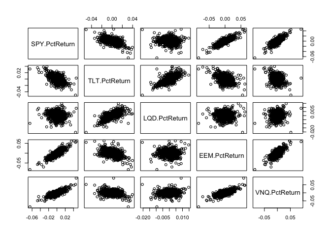

```r
myreturns = YahooPricesToReturns(myprices)
pairs(myreturns)
```

```r
apply(myreturns, 2, sd)
```

```
## SPY.PctReturn TLT.PctReturn LQD.PctReturn EEM.PctReturn VNQ.PctReturn
##   0.009354486   0.009769863   0.003579966   0.013729404   0.011523419
```

From the plot of the returns, we can figure out the following fact:

- returns on SPY, EEM and VNQ are positively correlated
- returns on SPY and TLT are negatively correlated
- returns on TLT and LQD are positively correlated
- returns on LQD has no obviouse correlation with SPY, EEM and VNQ

From the standard deviation of the returns, we can see that:

- EEM is the most risky assets, followed by VNQ
- LQD is the least risky assets

### Evenly Split Portfolio

Simulation on evenly split portfolio, with weights being 0.2, 0.2, 0.2, 0.2, 0.2

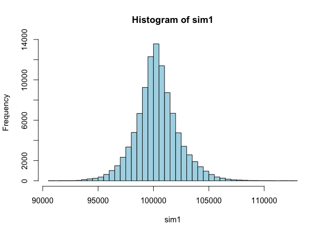

```r
sim1 = foreach(i = 1:5000, .combine = 'cbind')%do% {
  total_wealth = 100000
  weights = c(0.2, 0.2, 0.2, 0.2, 0.2)
  holdings = total_wealth * weights
  n_days = 20
  wealthtracker = rep(0, 20)
  for (today in 1:n_days) {
    return.today = resample(myreturns, 1, orig.ids = FALSE)
    holdings = holdings + holdings * return.today
    total_wealth = sum(holdings)
    wealthtracker[today] = total_wealth
  }
  wealthtracker
}

hist(sim1, 70, col = "Light Blue")
```

```r
risk1 = quantile(sim1, 0.05) - 100000
risk1
```

```
##        5%
## -2792.256
```

### A Safer Portfolio

Based on the above analysis of standard deviation and correlation, a safer portfolio than evenly split will be the one with SPY, TLT and LQD, because SPY and TLT have a comparative level of risk but negatively correlated, and LQD is the safest assets among all of the assets.

The following is the simulation of a safer portfilio with weights being 0.3, 0.3, 0.4, 0, 0

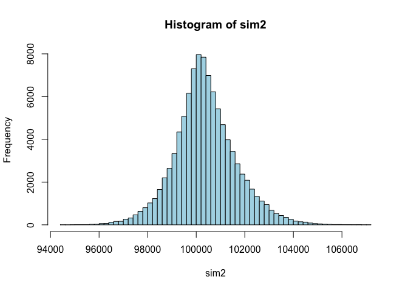

```r
sim2 = foreach(i = 1:5000, .combine = 'cbind')%do% {
  total_wealth = 100000
  weights = c(0.3, 0.3, 0.4, 0, 0)
  holdings = total_wealth * weights
  n_days = 20
  wealthtracker = rep(0, 20)
  for (today in 1:n_days) {
    return.today = resample(myreturns, 1, orig.ids = FALSE)
    holdings = holdings + holdings * return.today
    total_wealth = sum(holdings)
    wealthtracker[today] = total_wealth
  }
  wealthtracker
}
hist(sim2, 60, col = "Light Blue")
```

```r
risk2 = quantile(sim2, 0.05) - 100000
risk2
```

```
##        5%
## -1662.459
```

### A More Aggressive Portfolio

Similarly, a more regressive portfolio than the evenly split one would include EEM, VNQ and SPY, since they are not only positively correlated to each other but also have relatively high risk.

The simulation is the following:

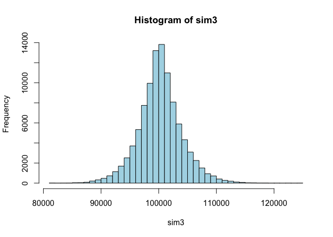

```r
sim3 = foreach(i = 1:5000, .combine = 'cbind')%do% {
  total_wealth = 100000
  weights = c(0.2, 0, 0, 0.6, 0.2)
  holdings = total_wealth * weights
  n_days = 20
  wealthtracker = rep(0, 20)
  for (today in 1:n_days) {
    return.today = resample(myreturns, 1, orig.ids = FALSE)
    holdings = holdings + holdings * return.today
    total_wealth = sum(holdings)
    wealthtracker[today] = total_wealth
  }
  wealthtracker
}
hist(sim3, 60, col = "Light Blue")
```

```r
risk3 = quantile(sim3, 0.05) - 100000
risk3
```

```
##        5%
## -5883.862
```

Now we have three options:

- The even split
  - 20% of your assets in each of the ETFs
  - The risk at 5% level is -2792.26.
- The safer option
  - 30% of your assets in SPY, 30% of you assets in TLT and the last 40% in LQD
  - The risk at 5% level is -1662.46.
- The more aggresive option
  - 20% of you assets in SPY, 20% of you assets in VNQ and the rest 60% in EEM
  - The risk at 5% level is -5883.86.

## Clustering and PCA

Load the library and the data.

```r
library(caret)
```

```r
library(ggplot2)
library(cclust)
wines = read.csv('../data/wine.csv')
```

Summarize the data to see the columns. Remove the last two columns which are quality and color, since we are only clustering with the first 11 features. Scale the wine data.

```r
wine = wines[, c(-12, -13)]
wine_scaled <- scale(wine, center = TRUE, scale = TRUE)
```

### k-means clustering

Since we know that we want two clusters seperating red and white wine, let’s start with kmeans with 2 centers.

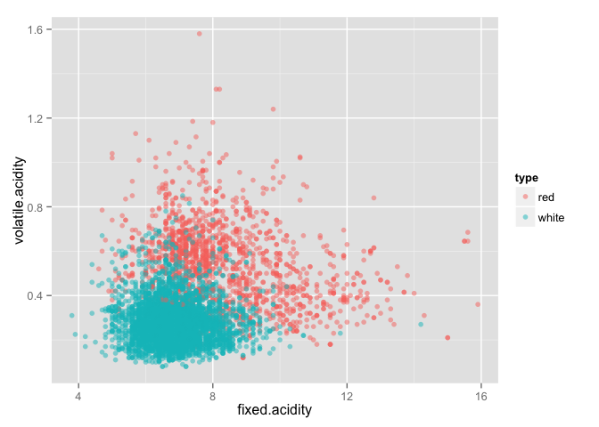

```r
wine_kmean <- kmeans(wine_scaled, centers=2, nstart = 50)
type = ifelse(wine_kmean$cluster == 1, "white", "red")
qplot(wines$fixed.acidity, wines$volatile.acidity, col = type, xlab = "fixed.acidity", ylab = "volatile.acidity", alpha = I(0.5))
```

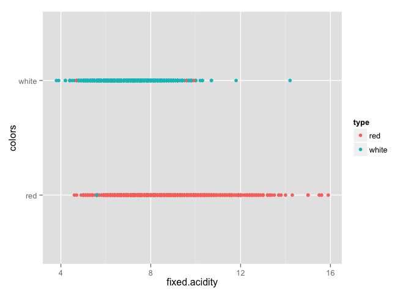

```r
qplot(wines$fixed.acidity, wines$color, col = type, xlab = "fixed.acidity", ylab = "colors")
```

This plot indicates the true classification of red and white wine in the y-axis, with the dots color representing the clustering result. Clearly, kmeans did a good job in clustering the color of the wine. Most red dots fall into the true red wine category, and most green dots fall into the true white wine category.

A confusion matrix can show us the accuracy of the classification.

```r
confusionMatrix(type, wines$color)
```

```
## Confusion Matrix and Statistics
##
##           Reference
## Prediction  red white
##      red   1575    68
##      white   24  4830
##
##                Accuracy : 0.9858
##                  95% CI : (0.9827, 0.9886)
##     No Information Rate : 0.7539
##     P-Value [Acc > NIR] : < 2.2e-16
##
##                   Kappa : 0.9622
##  Mcnemar's Test P-Value : 7.358e-06
##
##             Sensitivity : 0.9850
##             Specificity : 0.9861
##          Pos Pred Value : 0.9586
##          Neg Pred Value : 0.9951
##              Prevalence : 0.2461
##          Detection Rate : 0.2424
##    Detection Prevalence : 0.2529
##       Balanced Accuracy : 0.9856
##
##        'Positive' Class : red
##
```

Of all the 1599 kinds of red wine, 24 of them were clustered to white wine. The accuracy of classifying red wine is around 98.5%. Of 4898 kinds of white wine, 68 of them are misclassified by kmeans, and the accuracy is 98.61%.

However, can they tell the difference between different wine quality? Let’s split the data frame into two subset by their colors.

```r
red = wines[wines$color == "red", ]
white = wines[wines$color == "white", ]
red_scaled = scale(red[, c(-12, -13)], center = TRUE, scale = TRUE)
white_scaled = scale(white[, c(-12, -13)], center = TRUE, scale = TRUE)
```

Try kmeans on each subset to see whether kmeans can rank them.

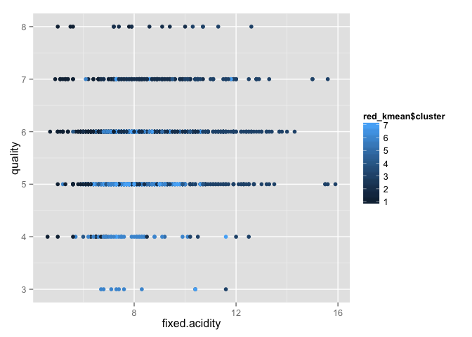

```r
red_kmean <- kmeans(red_scaled, centers = 7, nstart = 100)
qplot(red$fixed.acidity, red$quality, col = red_kmean$cluster, xlab = "fixed.acidity", ylab = "quality")
```

From the plot, we cannot see a clearly clustering by ranks. Try the same with white wine.

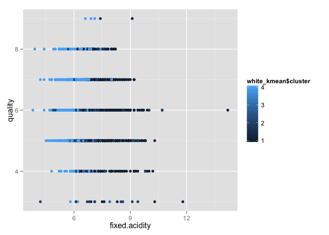

```r
white_kmean <- kmeans(white_scaled, centers = 4, nstart = 100)
qplot(white$fixed.acidity, white$quality, col = white_kmean$cluster, xlab = "fixed.acidity", ylab = "quality")
```

We still cannot tell the difference between each cluster in terms of their quality. It seems their quality are not determined by these 11 features.

## Principal Component Analysis

Apply PCA to the scaled wine data. Get the component vectors and the projection position on those vectors, named as scores.

```r
wine_pca <- prcomp(wine_scaled)
loadings = wine_pca$rotation
scores = wine_pca$x
```

Plot the red and white wine with x being the first component and y being the second component.

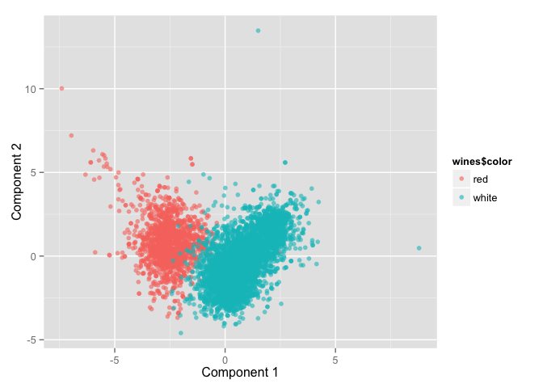

```r
qplot(scores[,1], scores[,2], color=wines$color, xlab='Component 1', ylab='Component 2', alpha = I(0.6))
```

Clearly, most kinds of wine, including both red and white, fall into the range of [-5, 5] in temrs of component 2. On the contrary, component 1 can seperate the two kinds of wine into two category. That is to say, component 1 itself is interesting enough in terms of telling the difference between wine color, while component 2 is does not provide much extra information. Since component 2 is not interesting to us, there’s no need to consider the rest components.

However, PCA doesn’t seem work well when we want to know the scores of the wine. Let’s take a look at the plot with color representing different scores.

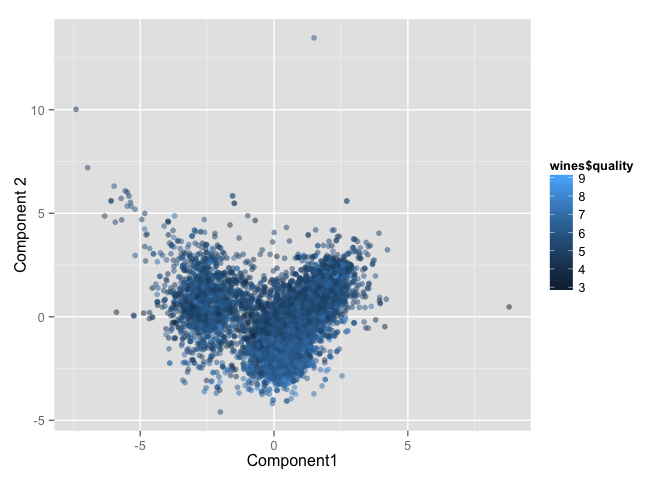

```r
qplot(scores[, 1], scores[, 2], color = wines$quality, xlab = "Component1", ylab = "Component 2", alpha = I(0.5))
```

Even component 1 and component 2 together are not enough to order the quality of these wine.

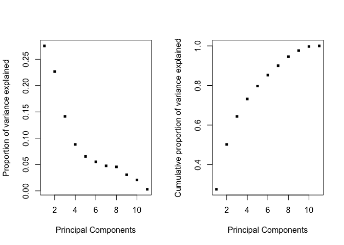

```r
vars <- (wine_pca$sdev)^2
sum <- sum(vars)
percent <- vars/sum
par(mfrow = c(1, 2))
plot(percent, xlab = "Principal Components", ylab = "Proportion of variance explained", cex = 0.7, pch = 15, col = 9)
plot(cumsum(percent), xlab = "Principal Components", ylab = "Cumulative proportion of variance explained", cex = 0.7, pch = 15, col = 9)
```

```r
par(mfrow = c(1, 1))
```

In conclusion, PCA works well in distinguishing red and white wine, but not in ranking the quality.

## Market Segmentation

Load the library and the data. Take a look at the first row of the data set.

```r
library(cluster)
market <- read.csv("../data/social_marketing.csv")
head(market, 1)
```

```
##           X chatter current_events travel photo_sharing uncategorized
## 1 hmjoe4g3k       2              0      2             2             2
##   tv_film sports_fandom politics food family home_and_garden music news
## 1       1             1        0    4      1               2     0    0
##   online_gaming shopping health_nutrition college_uni sports_playing
## 1             0        1               17           0              2
##   cooking eco computers business outdoors crafts automotive art religion
## 1       5   1         1        0        2      1          0   0        1
##   beauty parenting dating school personal_fitness fashion small_business
## 1      0         1      1      0               11       0              0
##   spam adult
## 1    0     0
```

We don’t want the first column, “spam” column, “chatter” column and “uncategorized” column which does’t provide interesting information about the user. So delete these columns.

Scale the data because some of the topic might be tweeted more often than others.

```r
markets = market[, -1]
markets = markets[, -which(names(markets)=="spam")]
markets = markets[, -which(names(markets) == "chatter")]
markets = markets[, -which(names(markets) == "uncategorized")]
market_scaled <- scale(markets, center = TRUE, scale = TRUE)
```

Apply kmeans to the scaled data frame.

```r
center_num = 8
segments <- kmeans(market_scaled, centers =  center_num, nstart = 100)
```

Take a look at the clustering centers.

```r
segments$centers
```

```
##   current_events      travel photo_sharing     tv_film sports_fandom
## 1     0.10234034 -0.11272269  -0.025459271 -0.10705254     2.0249394
## 2    -0.09330702 -0.22207450  -0.147276970 -0.22458904    -0.3147726
## 3     0.01025367 -0.15952768   0.002424409 -0.15545129    -0.2087017
## 4     0.11780919  3.19186654  -0.057575455 -0.07686805    -0.2181462
## 5     0.08895021 -0.18557373  -0.126954494 -0.03844082     0.6355539
## 6     0.31876161  0.20430462   0.058709428  2.64827640    -0.1106166
## 7     0.17632541 -0.05991035   1.279706183 -0.14787147    -0.2099234
## 8    -0.05862658 -0.04421146   0.026826191  0.09302734    -0.1325942
##     politics        food      family home_and_garden        music
## 1 -0.2238752  1.80041211  1.45616807      0.15771029  0.032279123
## 2 -0.2838071 -0.37481987 -0.26822345     -0.13468126 -0.180055714
## 3 -0.1921082  0.41922856 -0.07854314      0.14777257  0.002940299
## 4  3.0479280  0.14597546 -0.09151735      0.04035434 -0.045743648
## 5  1.1907155 -0.17611672  0.23536706      0.13717972 -0.079069871
```

[output cut: 48 more lines]

Unscale the data and get mu and sigma.

```r
mu = attr(market_scaled,"scaled:center")
sigma = attr(market_scaled,"scaled:scale")
segments_unscaled = segments$centers * sigma + mu
```

### First Cluster

```r
rbind(segments$centers[1, ], segments_unscaled[1, ])
```

```
##      current_events     travel photo_sharing    tv_film sports_fandom
## [1,]      0.1023403 -0.1127227   -0.02545927 -0.1070525      2.024939
## [2,]      1.6561210  0.4376382    1.91090001  0.8904199      4.075406
##        politics     food   family home_and_garden      music       news
## [1,] -0.2238752 1.800412 1.456168       0.1577103 0.03227912 -0.1273002
## [2,]  0.6103146 2.395510 3.097752       0.4338241 1.45480138  1.1806714
##      online_gaming   shopping health_nutrition college_uni sports_playing
## [1,]   -0.08179991 0.06534396       -0.1558373  -0.1331629      0.1005606
## [2,]    0.71811450 1.11605018        1.3162718   1.9685223      0.5980016
##         cooking       eco  computers  business    outdoors    crafts
## [1,] -0.1045525 0.2011351 0.08527873 0.1098667 -0.08188459 0.6836269
## [2,]  1.2105911 2.0286479 1.54362427 0.9155513  0.67039844 2.2042756
##      automotive         art religion    beauty parenting     dating
## [1,]  0.1184945 -0.02105278 2.212255 0.3059454  2.097901 0.04723433
## [2,]  1.5272801  0.40866633 4.653867 3.5324705  5.612761 0.70478452
##        school personal_fitness    fashion small_business      adult
## [1,] 1.650587       -0.1114721 0.02218561     0.09453593 0.01348903
## [2,] 3.422570        1.3302309 0.70212073     0.58507318 0.72306310
```

### Second Cluster

```r
rbind(segments$centers[2, ], segments_unscaled[2, ])
```

```
##      current_events     travel photo_sharing    tv_film sports_fandom
## [1,]    -0.09330702 -0.2220745    -0.1472770 -0.2245890    -0.3147726
## [2,]     1.37174786  0.4505292     0.3989438  0.4069186     1.1268504
##        politics       food     family home_and_garden      music
## [1,] -0.2838071 -0.3748199 -0.2682235      -0.1346813 -0.1800557
## [2,]  0.3116018  0.7126138  0.5818051       0.1590893  0.6599428
##            news online_gaming    shopping health_nutrition college_uni
## [1,] -0.3167166    -0.2263096 -0.06882735       -0.3225482  -0.2447176
## [2,]  0.3302155     0.3560275  0.29379055        0.8247851   0.8404953
##      sports_playing    cooking        eco  computers   business   outdoors
## [1,]     -0.2318910 -0.3242998 -0.1729037 -0.2205636 -0.1470374 -0.3297594
## [2,]      0.5130675  0.4036207  1.2645416  1.5755560  0.3957518  0.6689136
##          crafts automotive        art   religion     beauty  parenting
## [1,] -0.2261261 -0.2518521 -0.2354686 -0.3072051 -0.2706794 -0.3077654
## [2,]  1.1053717  0.9338065  0.4978742  0.4026593  0.6212882  0.3817215
##          dating     school personal_fitness    fashion small_business
## [1,] -0.0870441 -0.2605304       -0.3294823 -0.2619612     -0.1438911
## [2,]  0.3629753  0.2465046        1.7967932  0.6552087      0.4793610
##           adult
## [1,] 0.01964096
## [2,] 0.95110285
```

### Third Cluster

```r
rbind(segments$centers[3, ], segments_unscaled[3, ])
```

```
##      current_events     travel photo_sharing    tv_film sports_fandom
## [1,]     0.01025367 -0.1595277   0.002424409 -0.1554513    -0.2087017
## [2,]     2.72478547  0.8703990   0.651933316  0.6857753     1.1080100
##        politics      food      family home_and_garden       music
## [1,] -0.1921082 0.4192286 -0.07854314       0.1477726 0.002940299
## [2,]  0.4813949 0.8349972  0.60085332       1.7137696 0.522846123
##             news online_gaming   shopping health_nutrition college_uni
## [1,] -0.09113928    -0.1156567 0.04981961         2.124562  -0.2078711
## [2,]  1.68562146     0.8739445 0.49366830         3.270065   0.4363961
##      sports_playing   cooking       eco   computers   business outdoors
## [1,]    -0.02790323 0.3778584 0.5406882 -0.06625756 0.07953593 1.628769
## [2,]     0.67934561 0.5699079 2.3575109  1.35752145 0.93852361 3.974636
##         crafts automotive         art   religion     beauty  parenting
## [1,] 0.0530624  -0.153498 -0.08652206 -0.1741099 -0.2158502 -0.1035918
## [2,] 1.9494705   1.877093  0.44518359  1.0432886  1.1275771  1.2019866
##         dating     school personal_fitness    fashion small_business
## [1,] 0.1865608 -0.1517849          2.07726 -0.1103322     -0.1079022
## [2,] 1.0083115  0.5873388          4.51601  0.9123164      0.3485336
##              adult
## [1,] -2.288329e-05
## [2,]  7.108194e-01
```

### Forth Cluster

```r
rbind(segments$centers[4, ], segments_unscaled[4, ])
```

```
##      current_events   travel photo_sharing     tv_film sports_fandom
## [1,]      0.1178092 3.191867   -0.05757546 -0.07686805    -0.2181462
## [2,]      1.2657066 9.786859    0.38337880  0.57385466     2.1009090
##      politics      food      family home_and_garden       music     news
## [1,] 3.047928 0.1459755 -0.09151735      0.04035434 -0.04574365 1.113599
## [2,] 7.608558 0.8212451  0.78265817      1.67723484  0.63215259 1.369472
##      online_gaming  shopping health_nutrition college_uni sports_playing
## [1,]    -0.1547610 -0.017923       -0.1600995  -0.0391807     0.02910975
## [2,]     0.4996434  1.503520        0.4027361   1.8638363     1.15114747
##          cooking       eco computers  business    outdoors    crafts
## [1,] -0.18378638 0.1875595  2.889599 0.5535938 -0.03883854 0.2124195
## [2,]  0.07004068 1.0762898  3.458030 1.6269389  0.31232804 1.7746510
##      automotive        art  religion     beauty   parenting    dating
## [1,] -0.1267721 -0.1622052 0.1038582 -0.1821938 0.008753798 0.3686079
## [2,]  1.1822016  0.6082688 1.1864700  1.2363821 2.606600155 0.8169554
##           school personal_fitness    fashion small_business      adult
## [1,] -0.08655386        -0.141129 -0.1560932      0.4080259 -0.1157275
## [2,]  1.25388230         1.289044  1.1070196      1.2761697  0.6301842
```

### Fifth Cluster

```r
rbind(segments$centers[5, ], segments_unscaled[5, ])
```

```
##      current_events     travel photo_sharing     tv_film sports_fandom
## [1,]     0.08895021 -0.1855737    -0.1269545 -0.03844082     0.6355539
## [2,]     1.78622573  1.0536939     0.6291201  0.72202090     2.1245330
##      politics       food    family home_and_garden       music     news
## [1,] 1.190715 -0.1761167 0.2353671       0.1371797 -0.07906987 2.568875
## [2,] 4.408836  0.3013033 1.1303659       3.0714852  1.03942317 3.678942
##      online_gaming    shopping health_nutrition college_uni sports_playing
## [1,]    -0.1399912 -0.07224083       -0.2634776  -0.1994166    -0.08695907
## [2,]     0.7092028  1.41989526        0.4078834   0.3588106     0.58967778
##         cooking        eco  computers    business  outdoors     crafts
## [1,] -0.2504689 -0.0583523 -0.1982753 -0.08066612 0.2821401 -0.1551434
## [2,]  1.2084448  0.4776924  1.3181513  0.94094539 0.9149648  0.6881576
##      automotive        art   religion     beauty  parenting      dating
## [1,]   2.546446 -0.1753129 -0.2019562 -0.1823232 0.02034776 -0.01829011
## [2,]   3.123279  0.4391304  0.2114974  1.0737626 1.60843043  0.80487847
##          school personal_fitness    fashion small_business       adult
## [1,] 0.01254789       -0.2490483 -0.2204624     -0.1326354 -0.08934443
## [2,] 1.01951719        1.0337386  1.5760111      0.4075160  1.24717030
```

### Sixth Cluster

```r
rbind(segments$centers[6, ], segments_unscaled[6, ])
```

```
##      current_events    travel photo_sharing  tv_film sports_fandom
## [1,]      0.3187616 0.2043046    0.05870943 2.648276    -0.1106166
## [2,]      2.7548349 3.4858248    0.56381557 7.831817     1.3549784
##        politics      food     family home_and_garden    music       news
## [1,] -0.0952232 0.0967449 -0.1244288       0.2980621 1.088913 0.01240974
## [2,]  1.2171241 0.8996807  0.6198449       1.5647071 4.135246 0.43183508
##      online_gaming  shopping health_nutrition college_uni sports_playing
## [1,]    -0.1735487 0.2035594       -0.1824872   0.4095228      0.1191506
## [2,]     0.4015362 3.2528020        0.8221662   1.1320869      1.1018956
##        cooking       eco  computers  business    outdoors    crafts
## [1,] -0.162927 0.1189900 -0.1502496 0.4172258 -0.09591099 0.6854384
## [2,]  1.212629 0.8018307  0.3966557 1.2591863  1.40456183 1.0256365
##      automotive      art    religion       beauty  parenting      dating
## [1,] -0.1844184 2.381752 -0.00347951 -0.006161053 -0.1980572 -0.04786894
## [2,]  1.3656794 5.656056  0.39701419  0.856889265  0.4459697  0.64680998
##           school personal_fitness    fashion small_business       adult
## [1,] -0.01216216       -0.1588109 -0.0218028      0.8250215 -0.02307904
## [2,]  0.32881795        1.1155102  1.4863137      1.9569694  0.95437648
```

People from this group love to talk about current events, tv and film, about music, about art and small business. These people are those fantastic artists, musicians, movie makers!

### Seventh Cluster

```r
rbind(segments$centers[7, ], segments_unscaled[7, ])
```

```
##      current_events      travel photo_sharing    tv_film sports_fandom
## [1,]      0.1763254 -0.05991035      1.279706 -0.1478715    -0.2099234
## [2,]      1.7105638  1.37591028      2.578137  0.7262044     1.1523308
##        politics       food     family home_and_garden     music
## [1,] -0.1269455 -0.2022049 0.04039369       0.1389957 0.5354292
## [2,]  1.9964766  0.3506883 1.55922214       1.8943698 2.3578771
##             news online_gaming  shopping health_nutrition college_uni
## [1,] -0.08776632   -0.03405535 0.3216336      -0.06799234 -0.02106146
## [2,]  0.67651751    0.72723197 1.6038072       1.02610322  0.40866032
##      sports_playing   cooking        eco  computers  business   outdoors
## [1,]      0.2003425  2.686705 0.04897007 0.07089596 0.2608446 0.02545895
## [2,]      1.0679400 10.035538 1.30840694 0.73269231 1.3166129 1.64319099
##         crafts automotive          art   religion   beauty   parenting
## [1,] 0.1053613 0.03726068 -0.002247328 -0.1291657 2.533378 -0.06738273
## [2,] 0.7877930 0.54098699  0.702166744  1.3623652 2.386998  1.76710503
##         dating    school personal_fitness  fashion small_business
## [1,] 0.1190659 0.2035893      -0.04259446 2.596600      0.2025449
## [2,] 1.3233981 0.7725185       0.81562618 3.172205      1.0548783
##          adult
## [1,] 0.0130135
## [2,] 0.3443802
```

### Eighth Cluster

```r
rbind(segments$centers[8, ], segments_unscaled[8, ])
```

```
##      current_events      travel photo_sharing    tv_film sports_fandom
## [1,]    -0.05862658 -0.04421146    0.02682619 0.09302734    -0.1325942
## [2,]     0.79746881  0.59604885    0.76853134 0.39384051     1.1620594
##        politics        food    family home_and_garden       music
## [1,] -0.1622641 -0.09285402 0.2004677      0.06992411 -0.03386766
## [2,]  1.0793757  0.70301291 1.3631121      2.00058025  2.41496792
##            news online_gaming    shopping health_nutrition college_uni
## [1,] -0.2022025      3.501001 -0.07483086       -0.1891986    3.235237
## [2,]  0.3506903      9.882827  1.43230837        1.0471370    4.695633
##      sports_playing    cooking         eco   computers    business
## [1,]       2.074719 -0.1327845 -0.04725155 -0.09012065 -0.09767463
## [2,]       3.233003  0.8500260  1.08184337  0.36084519  0.53677011
##        outdoors     crafts automotive       art   religion     beauty
## [1,] -0.1497045 0.02968489 0.06190603 0.2673161 -0.1894617 -0.2330209
## [2,]  2.2878580 1.26789303 0.72208911 1.3264195  1.1519834  0.4392543
##       parenting       dating     school personal_fitness     fashion
## [1,] -0.1474759 -0.004293009 -0.1915336       -0.1921075 -0.06539505
## [2,]  0.3987907  0.699450278  1.2832272        0.3791561  1.77392264
##      small_business        adult
## [1,]      0.1090475 -0.008615448
## [2,]      1.3042146  0.387700535
```